# Gráficos con ggplot2 (B): más elementos

Programación y manejo de datos con R (Slides 06-B)

Pedro J. Pérez

pedro.j.perez@uv.es

## 3. Más elementos de *ggplot2*

Como puedes imaginar, aún tenemos que ver más elementos de ggplot2: los títulos y leyendas, los ejes, el tema, coordenadas, etc… vamos a ello!!

## Más elementos de un ggplot()

- Ya hemos presentado los principales elementos de los gráficos hechos con ggplot2, pero es evidente que **un gráfico tiene más elementos**
- Lógicamente, **hay que conocerlos un poco** para poder ajustar los gráficos a nuestras necesidades y mejorar su calidad

Veremos algo de los siguientes elementos:

- Títulos del gráfico
- Themes
- Small multiples (o Facetting)
- Anotaciones
- Ejes
- Escalas
- Stats (transformaciones estadísticas)
- Position adjustments
- Coordenadas

## 3.1 Títulos del gráfico

Un gráfico para ser efectivo y mostrar su mensaje con claridad debe tener un título y/o subtítulo ilustrativos y mostrar información relevante sobre las variables que se grafican

Este tipo de elementos pueden modificarse de varias maneras, pero nos centraremos en la función *labs()*

## Añadiendo títulos, leyenda, etc …a un ggplot

```r
p <- ggplot(iris, aes(Sepal.Length, Petal.Length, color = Species)) +
        geom_point()
```

```r
p +
```

```r
p +
labs(title = "Gráfico 1: Longitud del sépalo frente al pétalo") +
```

```r
p +
labs(title = "Gráfico 1: Longitud del sépalo frente al pétalo") +
labs(subtitle = "(diferenciando por especie de lirio)") +
```

```r
p +
labs(title = "Gráfico 1: Longitud del sépalo frente al pétalo") +
labs(subtitle = "(diferenciando por especie de lirio)") +
labs(caption = "Datos provenientes del Iris dataset") +
```

```r
p +
labs(title = "Gráfico 1: Longitud del sépalo frente al pétalo") +
labs(subtitle = "(diferenciando por especie de lirio)") +
labs(caption = "Datos provenientes del Iris dataset") +
labs(x = "Longitud del sépalo") +
```

```r
p +
labs(title = "Gráfico 1: Longitud del sépalo frente al pétalo") +
labs(subtitle = "(diferenciando por especie de lirio)") +
labs(caption = "Datos provenientes del Iris dataset") +
labs(x = "Longitud del sépalo") +
labs(y = "Longitud del pétalo") +
```

```r
p +
labs(title = "Gráfico 1: Longitud del sépalo frente al pétalo") +
labs(subtitle = "(diferenciando por especie de lirio)") +
labs(caption = "Datos provenientes del Iris dataset") +
labs(x = "Longitud del sépalo") +
labs(y = "Longitud del pétalo") +
labs(color = "Especie de lirio") +
```

```r
p +
labs(title = "Gráfico 1: Longitud del sépalo frente al pétalo") +
labs(subtitle = "(diferenciando por especie de lirio)") +
labs(caption = "Datos provenientes del Iris dataset") +
labs(x = "Longitud del sépalo") +
labs(y = "Longitud del pétalo") +
labs(color = "Especie de lirio") +
labs(tag = "Plot 1")
```

El chunk no se suele escribir de esa forma, sino así. Lo guardamos como `p_t`: a partir de ahora usaremos `p` (sin títulos) y `p_t` (con títulos)

```r
p_t <- p +
labs(title = "Gráfico 1: Longitud del sépalo frente al pétalo",
    subtitle = "(diferenciando por especie de lirio)",
    caption = "Datos provenientes del Iris dataset",
    x = "Longitud del sépalo",
    y = "Longitud del pétalo",
    color = "Especie de lirio",
    tag = "Plot 1")
```

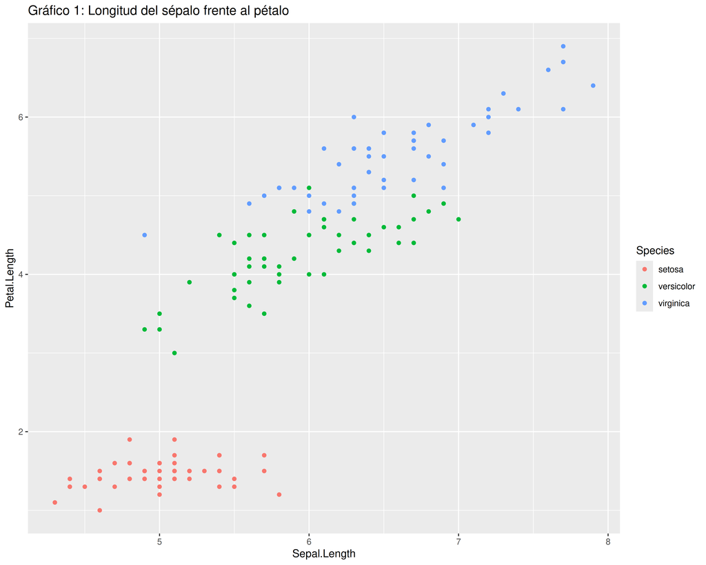

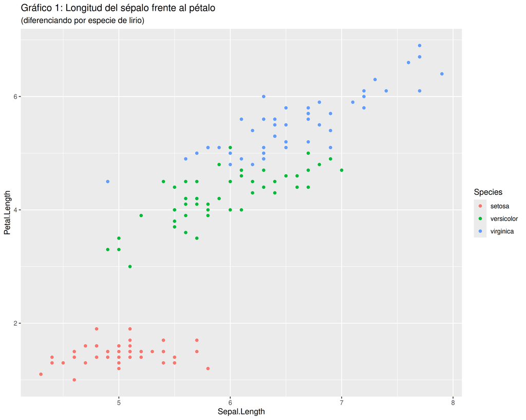

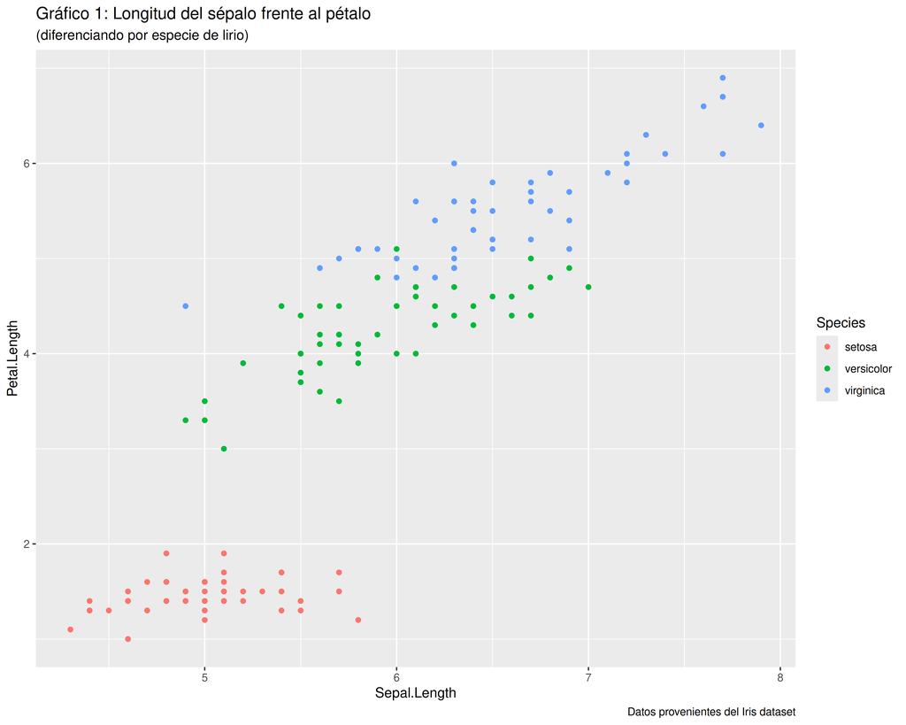

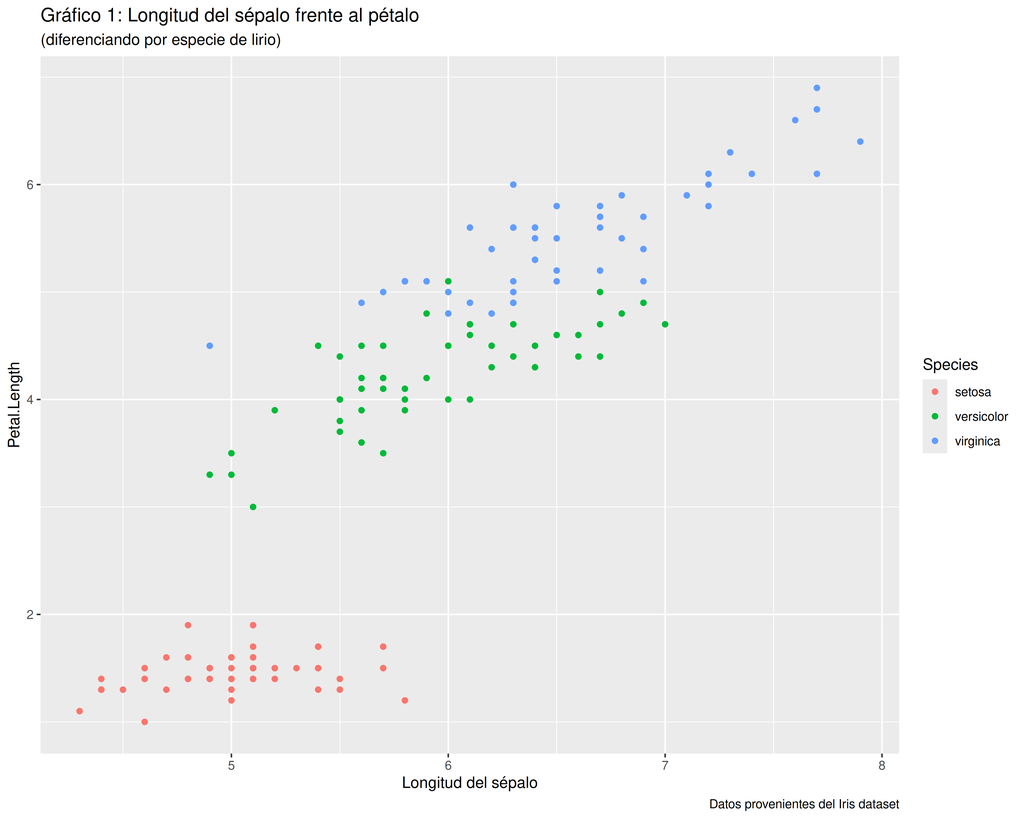

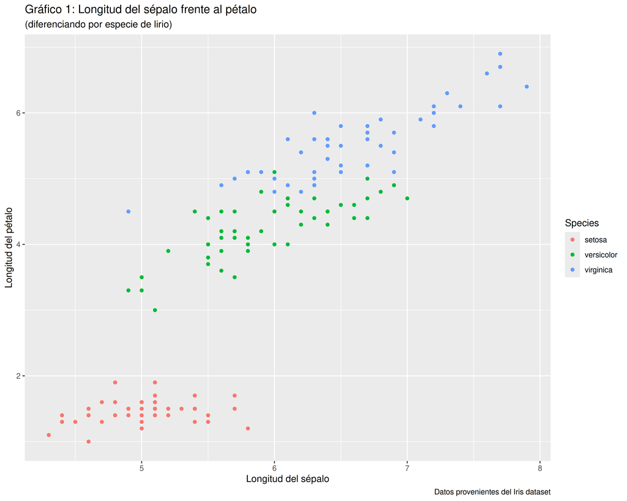

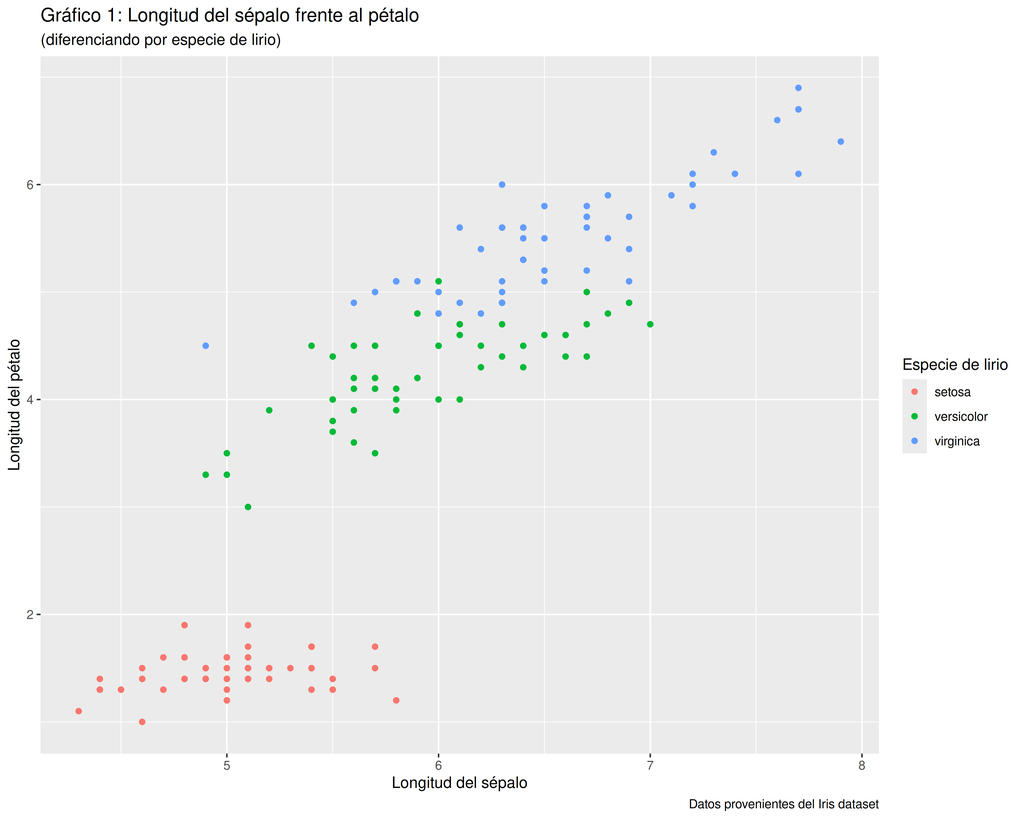

## A veces interesa eliminar elementos de los labels/títulos

```r
p +
```

```r
p +
labs(color = NULL) + #- borra el título de la leyenda
```

```r
p +
labs(color = NULL) + #- borra el título de la leyenda
labs(x = NULL) + #- borra el título del eje X
```

```r
p +
labs(color = NULL) + #- borra el título de la leyenda
labs(x = NULL) + #- borra el título del eje X
labs(subtitle = NULL) +
```

```r
p +
labs(color = NULL) + #- borra el título de la leyenda
labs(x = NULL) + #- borra el título del eje X
labs(subtitle = NULL) +
labs(caption = NULL) +
```

```r
p +
labs(color = NULL) + #- borra el título de la leyenda
labs(x = NULL) + #- borra el título del eje X
labs(subtitle = NULL) +
labs(caption = NULL) +
labs(title = NULL) +
```

```r
p +
labs(color = NULL) + #- borra el título de la leyenda
labs(x = NULL) + #- borra el título del eje X
labs(subtitle = NULL) +
labs(caption = NULL) +
labs(title = NULL) +
labs(y = NULL)  + #- borra el título del eje Y
```

```r
p +
labs(color = NULL) + #- borra el título de la leyenda
labs(x = NULL) + #- borra el título del eje X
labs(subtitle = NULL) +
labs(caption = NULL) +
labs(title = NULL) +
labs(y = NULL)  + #- borra el título del eje Y
labs(tag = NULL)
```

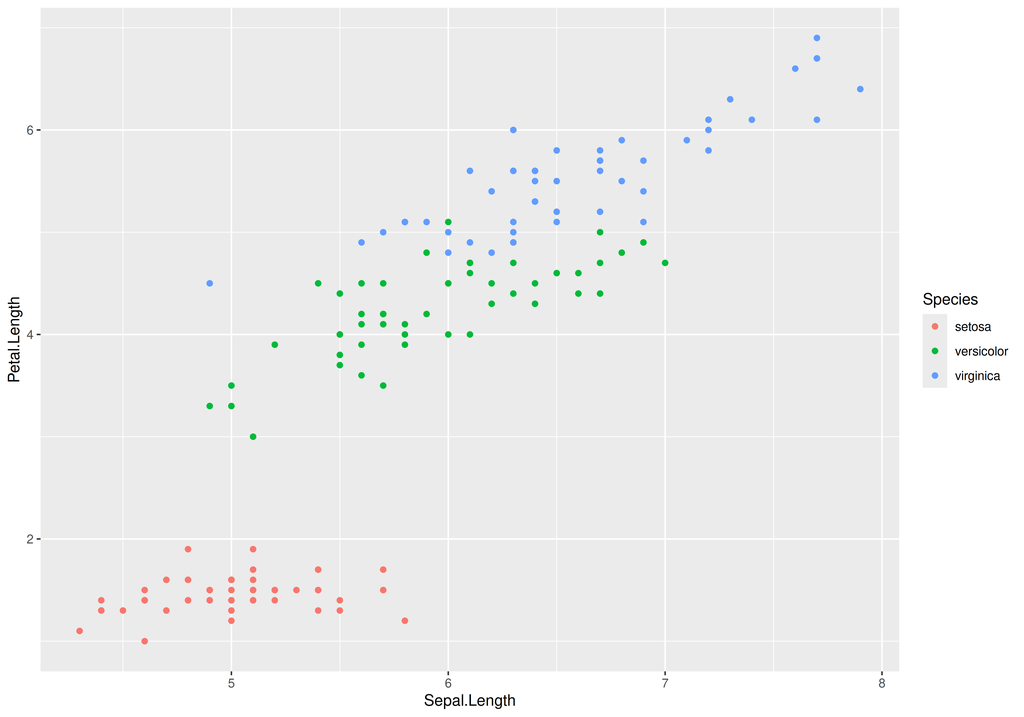

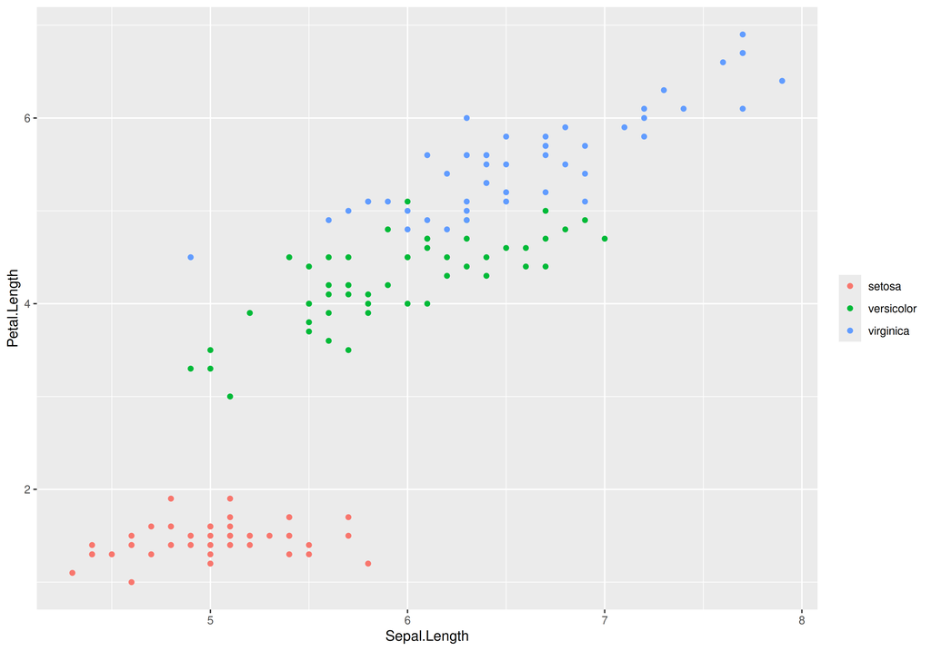

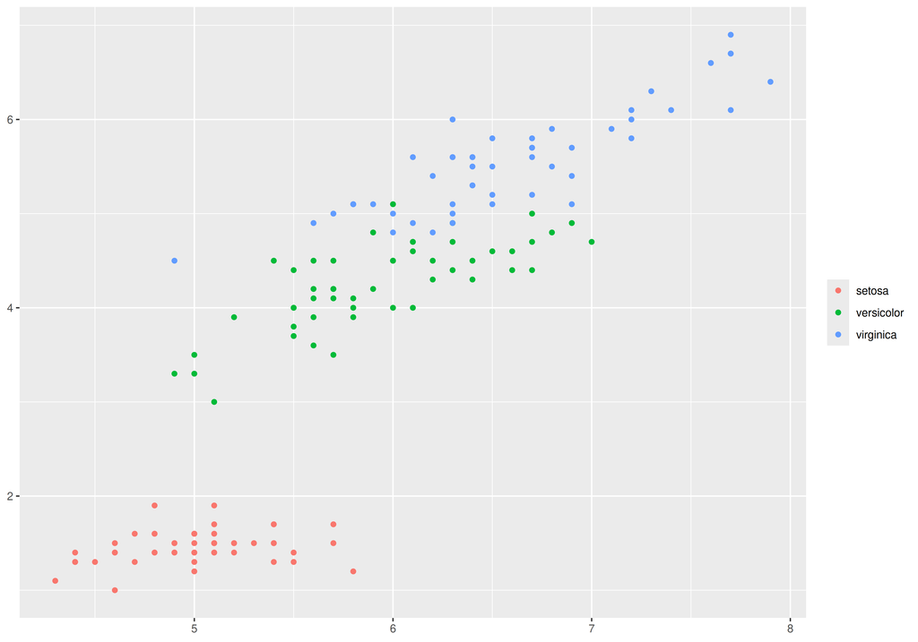

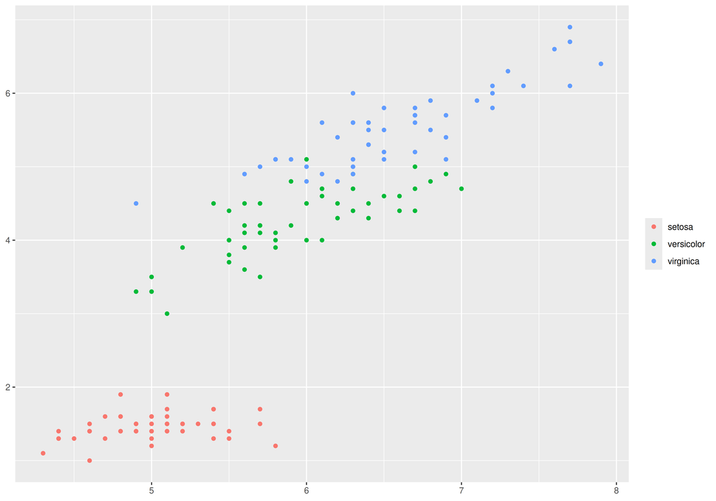

- Para los labels de los ejes X e Y es muy frecuente usar: `xlab(NULL)` y `ylab(NULL)`
- Queda la leyenda. La leyenda no es un elemento de los labels/título, sino del theme. Se puede eliminar con: `theme(legend.position = "none")`

## 3.2 Theme: cambiando la apariencia del gráfico

Los *themes* controlan la apariencia de todo lo que no son los datos. Podemos usar un tema completo, como *theme_bw()*, o ajustar elementos concretos con *theme()*

## Theme: cambiando la apariencia del gráfico

- Podemos cambiar los detalles de la apariencia del gráfico; por ejemplo, el tamaño, *fuente* y color de los títulos, pero también de los puntos, las líneas, el fondo del gráfico, la apariencia de las grid-lines, el lugar para las leyendas, etc … etc …. Para hacerlo hay que usar las “funciones de tema”. Todas ellas comienzan con **theme_()**
- En general con las funciones theme_() podemos cambiar/ajustar cualquier elemento del gráfico, con la excepción de la propia representación de los datos (ya sabemos que esto se hacen con las funciones geom_()). Estos elementos **afectan a la apariencia y detalles del gráfico, pero no a la relación entre variables que se muestra realmente en el gráfico**

## Themes/Temas predefinidos

```r
p_t +
```

```r
p_t +
theme_gray()  + #- tema por defecto
```

```r
p_t +
theme_gray()  + #- tema por defecto
theme_light() +
```

```r
p_t +
theme_gray()  + #- tema por defecto
theme_light() +
theme_dark() +
```

```r
p_t +
theme_gray()  + #- tema por defecto
theme_light() +
theme_dark() +
theme_classic() +
```

```r
p_t +
theme_gray()  + #- tema por defecto
theme_light() +
theme_dark() +
theme_classic() +
theme_minimal() +
```

```r
p_t +
theme_gray()  + #- tema por defecto
theme_light() +
theme_dark() +
theme_classic() +
theme_minimal() +
theme_void()
```

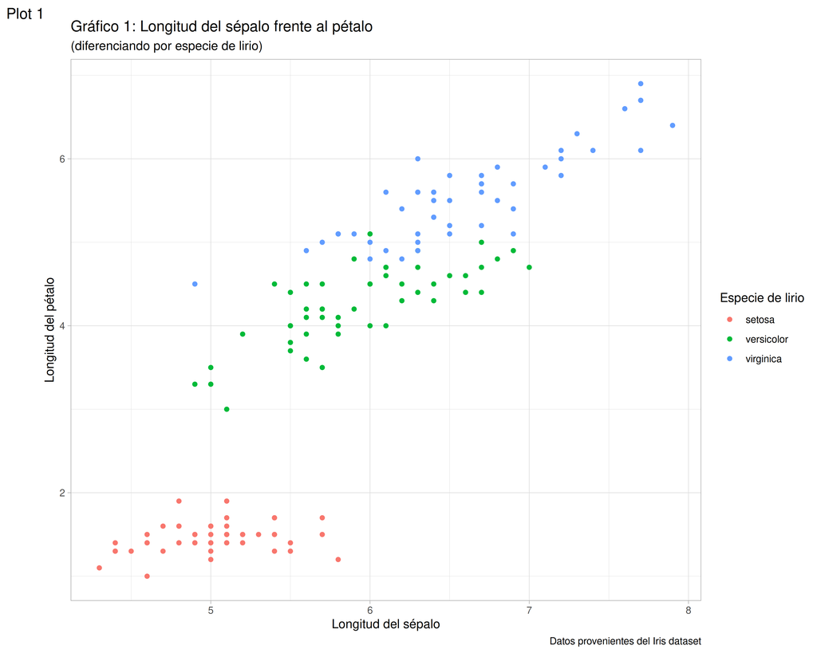

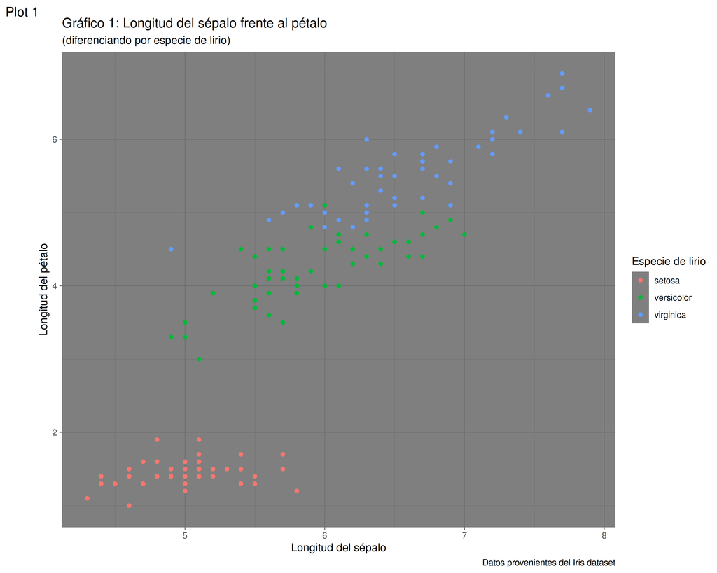

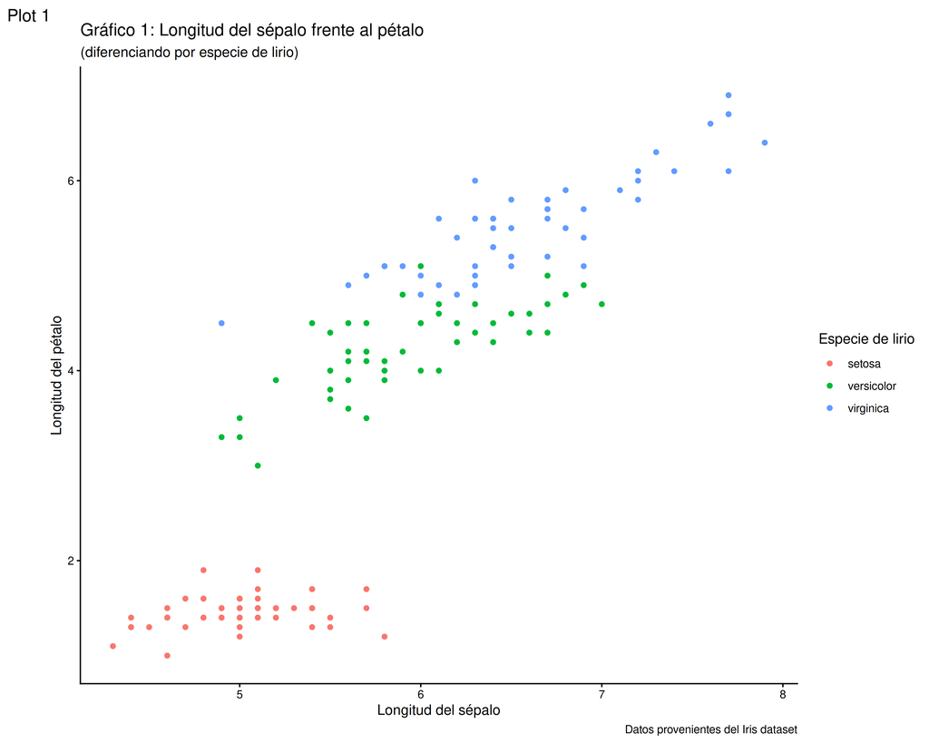

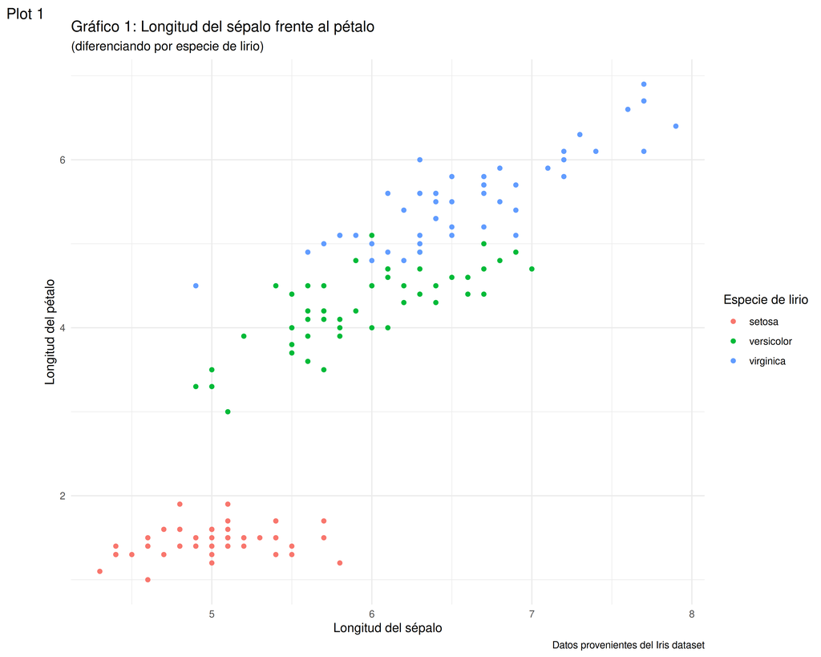

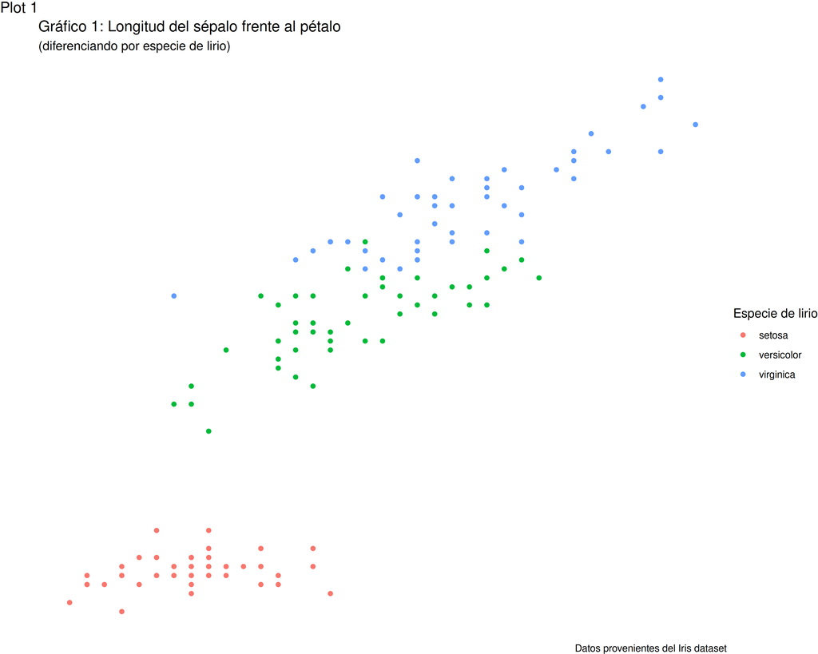

## En el pkg ggthemes hay muchos themes

```r
library(ggthemes)
```

```r
library(ggthemes)
p_t +
```

```r
library(ggthemes)
p_t +
theme_economist() +
```

```r
library(ggthemes)
p_t +
theme_economist() +
theme_fivethirtyeight() +
```

```r
library(ggthemes)
p_t +
theme_economist() +
theme_fivethirtyeight() +
theme_stata() +
```

```r
library(ggthemes)
p_t +
theme_economist() +
theme_fivethirtyeight() +
theme_stata() +
theme_solarized() +
```

```r
library(ggthemes)
p_t +
theme_economist() +
theme_fivethirtyeight() +
theme_stata() +
theme_solarized() +
theme_excel()
```

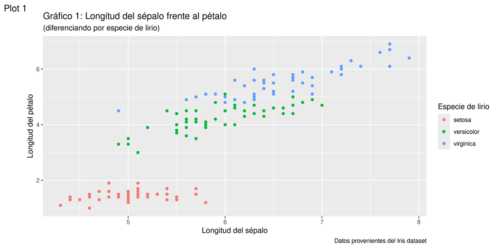

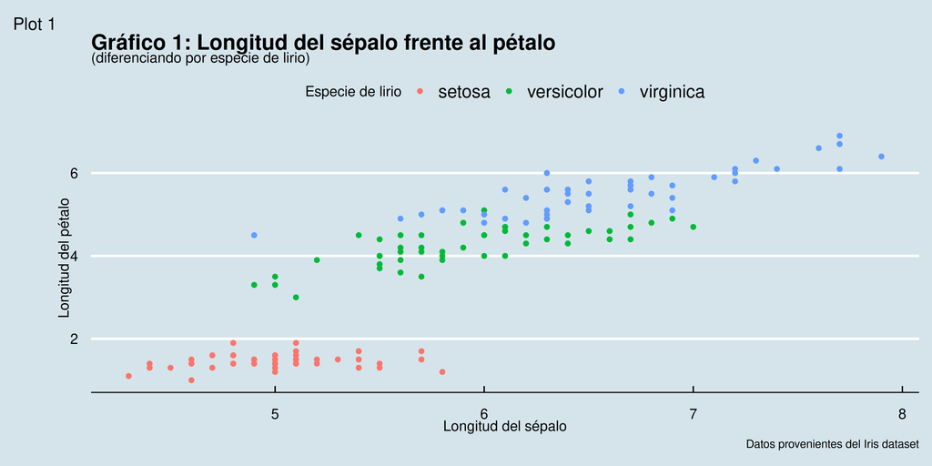

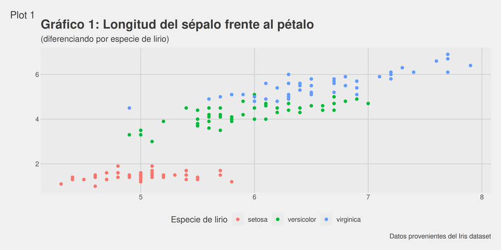

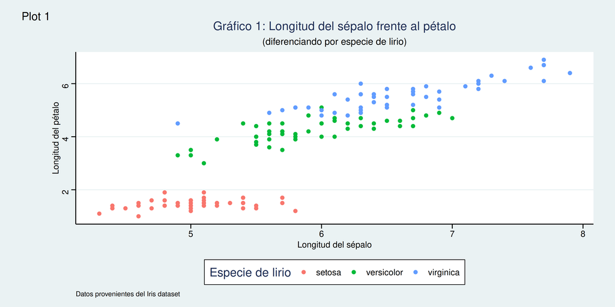

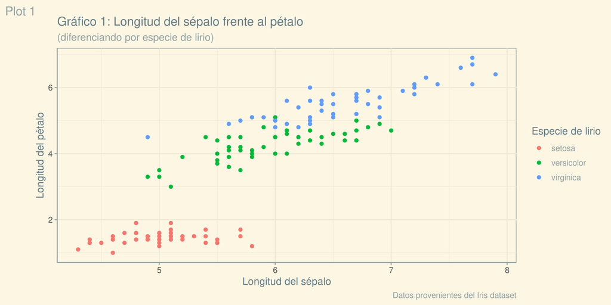

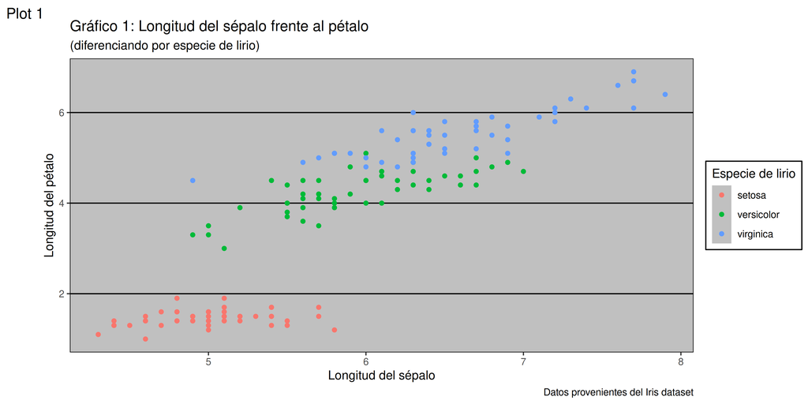

Si te interesa el tema de los themes. [[Aquí]](https://github.com/jrnold/ggthemes) tienes el repo de ggthemes y [[aquí]](https://yutannihilation.github.io/allYourFigureAreBelongToUs/ggthemes/) puedes ver más ejemplos de themes.

## ¿Puedo definir mi propio theme? Sí, absolutely.

```r
my_theme <- theme(
  axis.text.x = element_text(colour = "red", angle = 45, hjust = 1) ,
  axis.text.y = element_text(colour = "#7700AA",  size = 14) ,
  text = element_text(size = 16))

p_t + my_theme
```

Podemos fijar el theme (para los siguientes gráficos)

```r
#-podemos fijar un theme concreto
theme_set(theme_minimal())

# podemos fijar un theme y variar algún elemento (p.ej: eje X sin ticks ni escalas)
theme_set(theme_minimal() + theme(axis.text.x = element_blank()))

# si queremos volver al default theme
theme_set(theme_gray())
```

## `theme()`: 3 tipos de elementos [ 🌟 ]

- Con `theme()` se puede cambiar TODO. Pero en un gráfico solo hay 3 tipos de elementos: **textos**, **líneas** y **rectángulos**. Cada tipo se cambia con su función, y todos se quitan con `element_blank()`. La sintaxis es siempre la misma: `theme(elemento = element_tipo(...))`
- Textos
- Líneas
- Rectángulos
- Quitar

```r
p_t + theme(plot.title = element_text(colour = "blue"),
            axis.text.x = element_text(angle = 45))
```

`text` afecta a todos los textos a la vez: `theme(text = element_text(size = 16))`

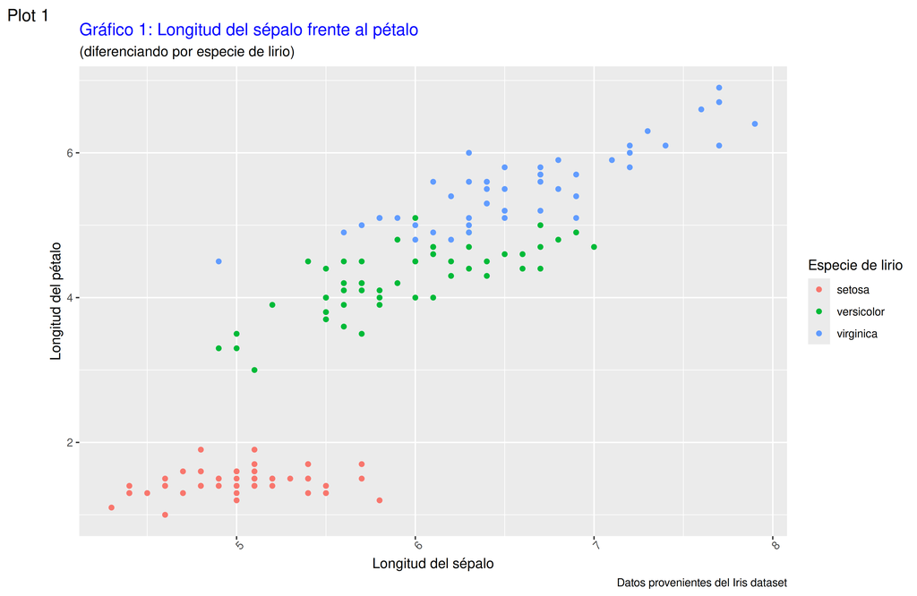

```r
p + theme(panel.grid =
            element_line(colour = "purple",
                         linetype = "dashed"))
```

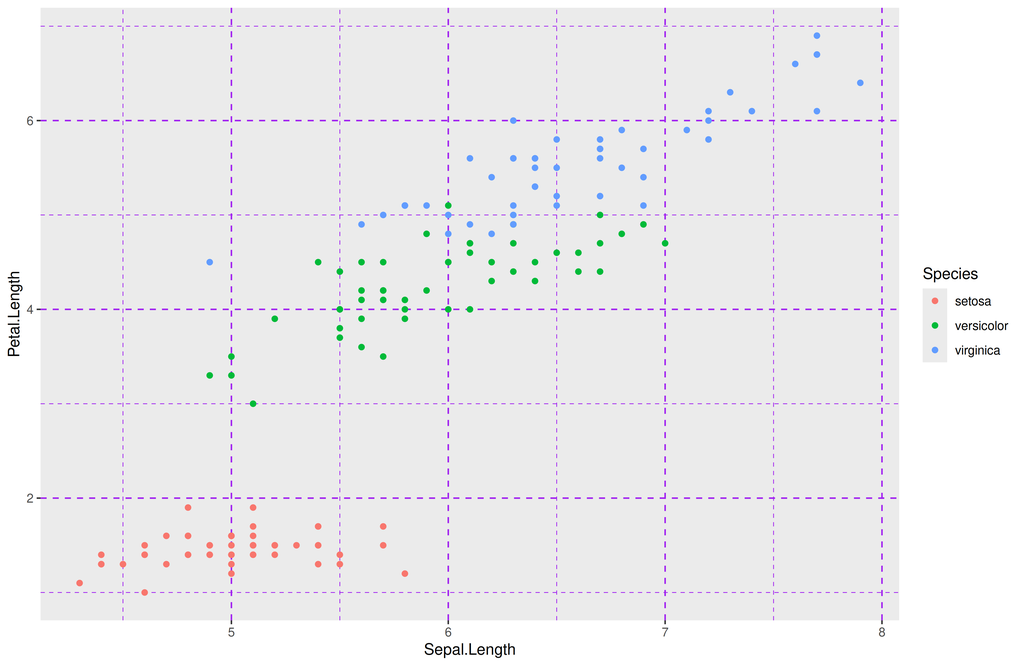

```r
p + theme(panel.background =
            element_rect(fill = "lightyellow",
                         colour = "black"),
          plot.background =
            element_rect(fill = "grey90"))
```

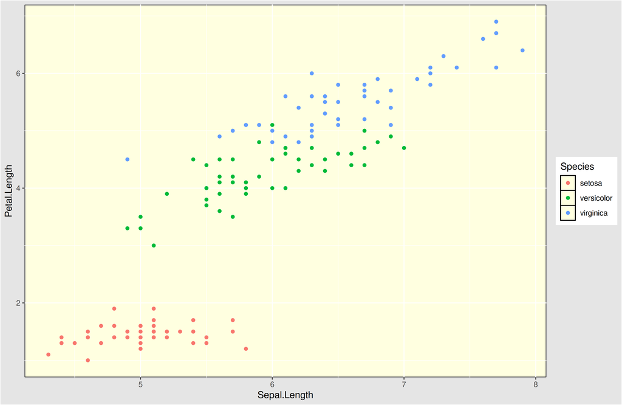

```r
p + theme(panel.background = element_blank(),
          panel.grid.minor = element_blank(),
          axis.ticks = element_blank())
```

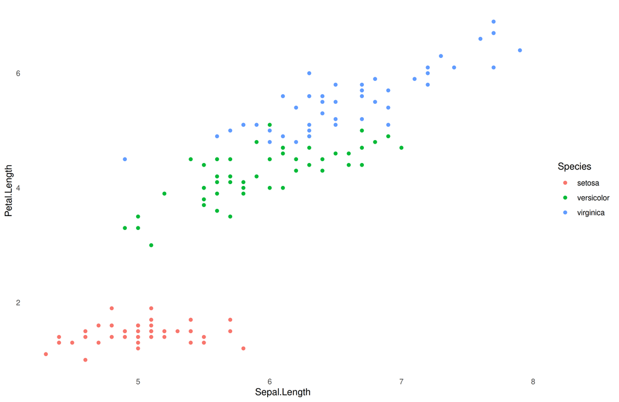

## La leyenda

- La leyenda la crea ggplot2 al mapear una variable (`color = Species`). Lo que más se suele hacer con ella:

```r
#- quitarla
p + theme(legend.position = "none")
p + guides(color = "none")

#- quitarle el título
p + labs(color = NULL)
p + theme(legend.title = element_blank())

#- cambiarla de sitio
p + theme(legend.position = "bottom")
p + theme(legend.position = "inside",
          legend.position.inside = c(0.85, 0.2))
```

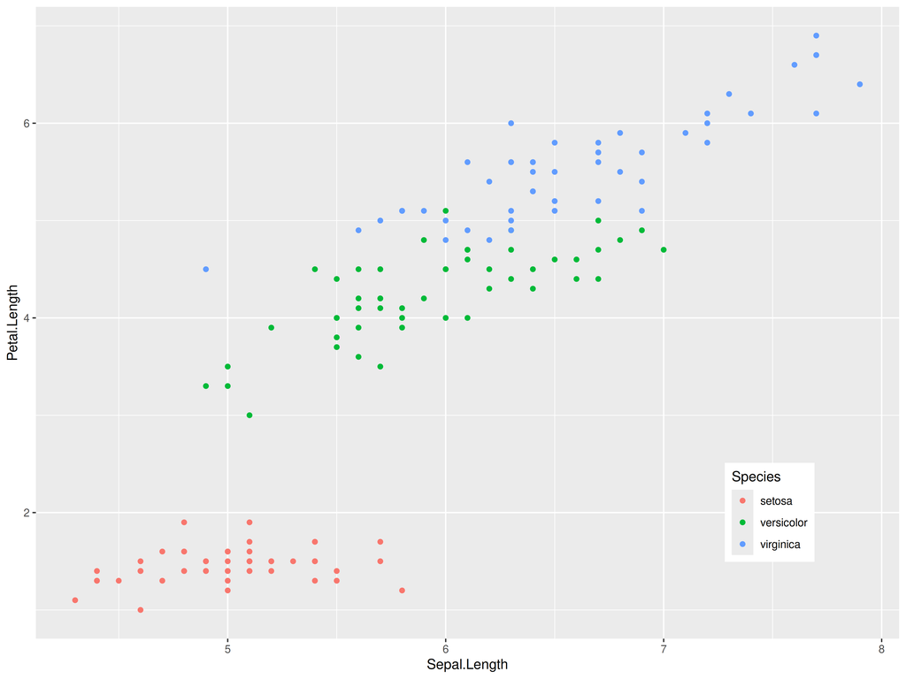

- El título de la leyenda se cambia con `labs()` (`labs(color = "Especie")`); su aspecto, con `theme()` (`legend.title`, `legend.text`, …)

## ¿Cómo se llaman todos los elementos del gráfico?

[figure not shown]

- En este [tweet de Henry Wang](https://x.com/henrywangnl/status/1259396196713537536) hay una imagen con los nombres de todos los elementos de un gráfico ggplot (y la función `element_xx()` que los modifica). La explicación completa está en [su blog](https://henrywang.nl/ggplot2-theme-elements-demonstration/)
- También se pueden ver, casi mejor, [aquí](https://isabella-b.com/blog/ggplot2-theme-elements-reference/)
- Los siguientes posts explican muy bien cómo tunear distintos elementos del theme: [rectangle elements](https://cmdlinetips.com/2021/06/7-tips-to-customize-rectangle-elements-in-ggplot2-element_rect/), [use element_blank()](https://cmdlinetips.com/2021/06/ggplot2-theme-element_blank-tips/), [element_line()](https://cmdlinetips.com/2021/05/tips-to-customize-lines-in-ggplot2-with-element_line/) y [element_text()](https://cmdlinetips.com/2021/05/tips-to-customize-text-color-font-size-in-ggplot2-with-element_text/)

## Colores ( 🖥 🎨 )

Sé poquito de colores, pero claro, si quieres cambiar la apariencia de los gráficos, has de saber los colores de R, así que:

- R tiene 657 colores con nombre. Para ver la lista ejecuta: `aa <- as.data.frame(colours())`
- Si sabes el nombre del color que quieres, [[aquí]](https://pkg.garrickadenbuie.com/r-colors-css/), podrás buscarlo y ver su color y su codificación en RGB y Hex
- También es interesante el [[paquete paleteer]](https://github.com/EmilHvitfeldt/paletteer) que agrupa un conjunto amplio de paletas de colores para usar en R

## Paletas de colores (y daltonismo)

- Alrededor de un 8% de los hombres tiene algún tipo de daltonismo: el rojo y el verde de la paleta por defecto les cuesta distinguirlos
- Mejor usar **paletas pensadas para eso**: `viridis` (viene con ggplot2) o algunas de [ColorBrewer](https://colorbrewer2.org/) como `"Dark2"`

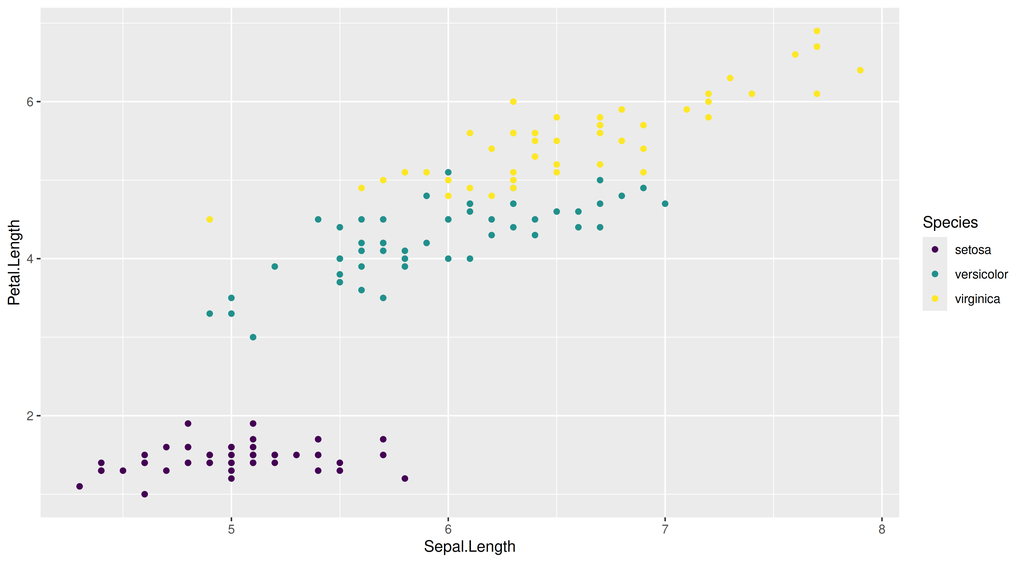

```r
p + scale_color_viridis_d()
```

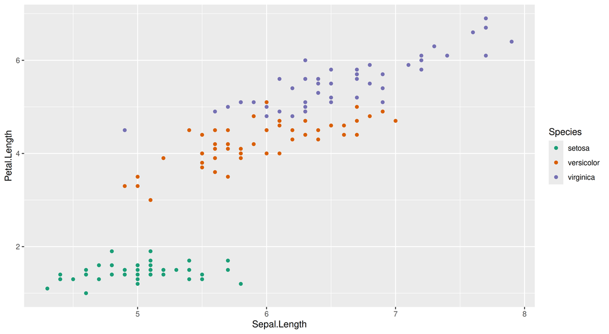

```r
p + scale_color_brewer(palette = "Dark2")
```

## Para practicar: themes

- Tarea
- Solución

Tarea: partiendo del gráfico `p`, ponle el tema `theme_minimal()`, lleva la leyenda abajo y haz que todos los textos del gráfico sean más grandes (tamaño 16)

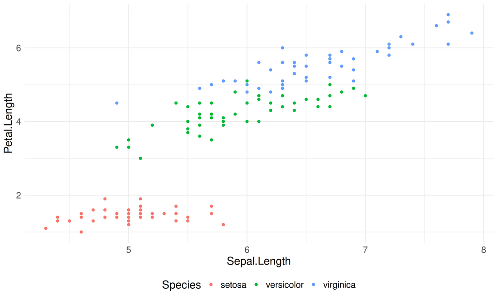

```r
p + theme_minimal() +
  theme(legend.position = "bottom",
        text = element_text(size = 16))
```

- Ojo con el orden: `theme_minimal()` va antes que `theme()`. Si lo pones después, el tema completo “pisa” tus cambios

## 3.3 Small multiples (o facetting)

El sistema gráfico de ggplot2 incorpora una técnica especial llamada “faceting” que permite dividir un gráfico en múltiples gráficos

Cada uno de esos múltiples gráficos se realiza sólo para las observaciones de uno de los valores de una variable categórica (o factor) incluido en el conjunto de datos. Es más fácil hacerlo que explicarlo/escribirlo